# **Location-scale Meta-analysis and Meta-regression as a Tool to Capture Large-scale Changes in Biological and Methodological Heterogeneity: a Spotlight on Heteroscedasticity**

- Show All Code
- Hide All Code
- View Source

Author

**Shinichi Nakagawa, Ayumi Mizuno, Kyle Morrison, Lorenzo Ricolfi, Coralie Williams, Szymon M Drobniak, Malgorzata Lagisz, and Yefeng Yang**

Published

April 18, 2025

# 1 Update

Last update February 2025.

We will update this tutorial when necessary. Readers can access the latest version in our [GitHub repository](https://github.com/itchyshin/location-scale_meta-analysis).

If you have any questions, errors or bug reports, please contact Dr. Yefeng Yang (yefeng.yang1@unsw.edu.au) or Professor Shinichi Nakagawa (snakagaw@ualberta.ca).

# 2 Introduction

This online material is a supplement to the paper about multilevel location-scale meta-analysis and meta-regression. The main aim of this online material is to provide a comprehensive hands-on guide for the implementation of location-scale meta-analysis and meta-regression. While we try to make this online material as stand-alone as possible (see below), we do not have too much explanation of the theories underpinning the location-scale meta-analysis and meta-regression. Therefore, we recommend readers to read the associated paper for theoretical background, formulas, and details on location-scale models in ecology and evolution.

# 3 Content

In this online material, we will illustrate how to fit:

- Normal random-effects meta-analyses (including a trick to speed up Markov chain Monte Carlo in `brms`)
- Location-scale random-effects meta-regression
- Multilevel meta-analysis and location-scale meta-regression, including categorical and continuous moderator variables (with a bonus about how to derive heterogeneity from these ‘new’ models)
- Multilevel location-scale meta-regression examining publication biases, including small-study effect, small-study divergence, time-lag bias, and Proteus effect

The illustration will be based on three publicly available datasets (which are corresponding to **Examples 1 to 3**). Thanks to the excellent work done by researchers such as Paul-Christian Bürkner and Wolfgang Viechtbauer, who have developed amazing software. Therefore, all illustrations will be based on readily available software such as the `R` packages `brms` (Bayesian implementation), `blsmeta` (Bayesian implementation) and `metafor` (frequentist implementation).

All results presented in this online material are for illustrative purposes only and should not be used to draw substantive conclusions or policy implications.

# 4 Prerequisites

## 4.1 Loading pacakges

Our tutorial uses `R` statistical software and existing `R` packages, which you will first need to download and install.

If the packages are archived in CRAN, use `install.packages()` to install them. For example, to install the `brms` , you can execute `install.packages("brms")` in the console (bottom left pane of `R Studio`). To install packages that are not on CRAN and archived in Github repositories, execute `devtools::install_github()`. For example, to install `blsmeta` from Github repository, execute `devtools::install_github("donaldRwilliams/blsmeta")` (make sure you have `devtools` installed; if not, execute `install.packages("devtools")`). For `orchaRd`, execute `devtools::install_github("daniel1noble/orchaRd", force = TRUE)`.

Version information of each package is listed at the end of this tutorial.

```r
# attempt to load or install necessary packages
if(!require(pacman)) install.packages("pacman")
pacman::p_load(
  tidyverse,
  tidybayes,
  here,
  patchwork,
  orchaRd, # devtools::install_github("daniel1noble/orchaRd", force = TRUE)
  ggplot2,
  pander,
  brms,
  metafor,
  blsmeta, # devtools::install_github("donaldRwilliams/blsmeta")
  ape,
  ggtree,
  bayesplot
)
```

## 4.2 Custom functions

We also provide some additional helper functions to help visualize the results (mainly extracted from the `brms` object). The most straightforward way to use these custom functions is to run the code chunk below. Alternatively, paste the code into the console and hit `Enter` to have `R` ‘learn’ these custom functions.

If you want to use these custom functions in your own data, you’ll need to change the variable names according to your own data (check out the `R` code and you’ll see what we mean).

```r
# Function to get variable names dynamically
get_variables_dynamic <- function(model, pattern) {
  variables <- get_variables(model)
  variables[grep(pattern, variables)]
}

rename_vars <- function(variable) {
  variable <- gsub("b_Intercept", "b_l_intercept", variable)
  variable <- gsub("b_sigma_Intercept", "b_s_intercept", variable)
  variable <- gsub("b_habitatterrestrial", "b_l_contrast", variable)
  variable <- gsub("b_sigma_habitatterrestrial", "b_s_contrast", variable)
  variable <- gsub("b_methodpersisitent", "b_l_contrast", variable)
  variable <- gsub("b_sigma_methodpersisitent", "b_s_contrast", variable)
  variable <- gsub("b_elevation_log", "b_l_elevation", variable)
  variable <- gsub("b_sigma_elevation_log", "b_s_elevation", variable)
  variable <- gsub("b_se", "b_l_se", variable) #
  variable <- gsub("b_sigma_se", "b_s_se", variable) #
  variable <- gsub("b_cyear", "b_l_cyear", variable) #
  variable <- gsub("b_sigma_cyear", "b_s_cyear", variable) #
  variable <- gsub("sd_study_ID__Intercept", "sd_l_study_ID", variable)
  variable <- gsub("sd_species_ID__Intercept", "sd_l_species_ID", variable)
  variable <- gsub("sd_phylogeny__Intercept", "sd_l_phylogeny", variable)
  variable <- gsub("sd_study_ID__sigma_Intercept", "sd_s_study_ID", variable)
  variable <- gsub("cor_study_ID__Intercept__sigma_Intercept", "cor_study_ID", variable)
  return(variable)
}


# Function to visualize fixed effects
visualize_fixed_effects <- function(model) {
  fixed_effect_vars <- get_variables_dynamic(model, "^b_")
  if (length(fixed_effect_vars) == 0) {
    message("No fixed effects found")
    return(NULL)
  }

  tryCatch({
    fixed_effects_samples <- model %>%
      spread_draws(!!!syms(fixed_effect_vars)) %>%
      pivot_longer(cols = all_of(fixed_effect_vars), names_to = ".variable", values_to = ".value") %>%
      mutate(.variable = rename_vars(.variable))

    ggplot(fixed_effects_samples, aes(x = .value, y = .variable)) +
      stat_halfeye(
        normalize = "xy",
        point_interval = "mean_qi",
        fill = "lightcyan3",
        color = "lightcyan4"
      ) +
      geom_vline(xintercept = 0, linetype = "dashed", color = "#005") +
      labs(y = "Fixed effects", x = "Posterior values") +
      theme_classic()
  }, error = function(e) {
    message("Error in visualize_fixed_effects: ", e$message)
    return(NULL)
  })
}

# Function to visualize random effects
visualize_random_effects <- function(model) {
  random_effect_vars <- get_variables_dynamic(model, "^sd_")
  random_effect_vars <- random_effect_vars[random_effect_vars != "sd_es_ID__Intercept"]
  if (length(random_effect_vars) == 0) {
    message("No random effects found")
    return(NULL)
  }

  tryCatch({
    random_effects_samples <- model %>%
      spread_draws(!!!syms(random_effect_vars)) %>%
      pivot_longer(cols = all_of(random_effect_vars), names_to = ".variable", values_to = ".value") %>%
      mutate(.variable = rename_vars(.variable)) #%>%
      #mutate(.value = .value)  # leave SD as it is

    ggplot(random_effects_samples, aes(x = .value, y = .variable)) +
      stat_halfeye(
        normalize = "xy",
        point_interval = "mean_qi",
        fill = "olivedrab3",
        color = "olivedrab4"
      ) +
      geom_vline(xintercept = 0, linetype = "dashed", color = "#005") +
      labs(y = "Random effects (SD)", x = "Posterior values") +
      theme_classic()
  }, error = function(e) {
    message("Error in visualize_random_effects: ", e$message)
    return(NULL)
  })
}

# Function to visualize correlations
visualize_correlations <- function(model) {
  correlation_vars <- get_variables_dynamic(model, "^cor_")
  if (length(correlation_vars) == 0) {
    message("No correlations found")
    return(NULL)
  }

  tryCatch({
    correlation_samples <- model %>%
      spread_draws(!!!syms(correlation_vars)) %>%
      pivot_longer(cols = all_of(correlation_vars), names_to = ".variable", values_to = ".value") %>%
      mutate(.variable = rename_vars(.variable))

    ggplot(correlation_samples, aes(x = .value, y = .variable)) +
      stat_halfeye(
        normalize = "xy",
        fill = "#FF6347",
        color = "#8B3626"
      ) +
      geom_vline(xintercept = 0, linetype = "dashed", color = "#005") +
      labs(y = "Correlations", x = "Posterior values") +
      theme_classic()
  }, error = function(e) {
    message("Error in visualize_correlations: ", e$message)
    return(NULL)
  })
}
```

# 5 Normal random-effects meta-analyses

To start off, we illustrate how to fit normal random-effects meta-analyses using three packages: `metafor`, `brms` and `blsmeta`. As you will see soon, all three packages lead to the same results.

## 5.1 Data

We use the data (hereafter **Example 1**) from the following paper:

> Pottier, P. et al. (2022). Developmental plasticity in thermal tolerance: Ontogenetic variation, persistence, and future directions. Ecology Letters, 25(10), 2245–2268.

```r
# load
dat <- read.csv(here("data", "thermal.csv"))
# select variables we need
dat <- dat %>% select(dARR, Var_dARR, es_ID, population_ID, study_ID, exp_design, habitat)
dat$study_ID <- as.numeric(dat$study_ID)
# create SE (sqrt(Var))
dat$si <- sqrt(dat$Var_dARR)

# for illustrative purpose, we create a new variable (method) according to the original paper
dat$method <- ifelse(dat$exp_design == c("A", "B", "C"), "initial", "persisitent")

# check the cleaned data
str(dat)
## 'data.frame':    1089 obs. of  9 variables:
##  $ dARR         : num  0.0528 0.0428 0.054 0.0115 0.0503 ...
##  $ Var_dARR     : num  0.000171 0.000192 0.000239 0.000131 0.000175 ...
##  $ es_ID        : int  1 2 3 4 5 6 7 8 9 10 ...
##  $ population_ID: int  1 1 2 2 2 3 3 3 3 3 ...
##  $ study_ID     : num  1 1 1 1 1 2 2 2 2 2 ...
##  $ exp_design   : chr  "D" "D" "D" "D" ...
##  $ habitat      : chr  "terrestrial" "terrestrial" "terrestrial" "terrestrial" ...
##  $ si           : num  0.0131 0.0139 0.0154 0.0114 0.0132 ...
##  $ method       : chr  "persisitent" "persisitent" "persisitent" "persisitent" ...
```

## 5.2 `metafor`

A normal random-effects meta-analysis can be easily fitted via `rma()` from `metafor`:

```r
# random effects - default
fit_ma5 <- rma(yi = dARR,
               vi = Var_dARR,
               test="t",
               data = dat)
```

Check the results:

```r
summary(fit_ma5)
##
## Random-Effects Model (k = 1089; tau^2 estimator: REML)
##
##    logLik   deviance        AIC        BIC       AICc
## -286.0953   572.1907   576.1907   586.1749   576.2018
##
## tau^2 (estimated amount of total heterogeneity): 0.0743 (SE = 0.0036)
## tau (square root of estimated tau^2 value):      0.2726
## I^2 (total heterogeneity / total variability):   99.34%
## H^2 (total variability / sampling variability):  151.25
##
## Test for Heterogeneity:
## Q(df = 1088) = 53884.2944, p-val < .0001
##
## Model Results:
##
## estimate      se     tval    df    pval   ci.lb   ci.ub
##   0.1708  0.0089  19.2520  1088  <.0001  0.1534  0.1882  ***
##
## ---
## Signif. codes:  0 '***' 0.001 '**' 0.01 '*' 0.05 '.' 0.1 ' ' 1
```

Alternatively, we can use `rma.mv()`. One potential benefit of using `rma.mv()` is that we can (through the use of sparse matrices) speed up model fitting when we have a large number of observations in our dataset (well, we don’t have a specific number for how large).

```r
# random effects - rma.mv
fit_ma6 <- rma.mv(yi = dARR,
                  V = Var_dARR,
                  random = ~ 1 | es_ID,
                  test="t",
                  data = dat,
                  sparse = T)
```

Check the results:

```r
summary(fit_ma6)
##
## Multivariate Meta-Analysis Model (k = 1089; method: REML)
##
##    logLik   Deviance        AIC        BIC       AICc
## -286.0953   572.1907   576.1907   586.1749   576.2018
##
## Variance Components:
##
##             estim    sqrt  nlvls  fixed  factor
## sigma^2    0.0743  0.2726   1089     no   es_ID
##
## Test for Heterogeneity:
## Q(df = 1088) = 53884.2944, p-val < .0001
##
## Model Results:
##
## estimate      se     tval    df    pval   ci.lb   ci.ub
##   0.1708  0.0089  19.2519  1088  <.0001  0.1534  0.1882  ***
##
## ---
## Signif. codes:  0 '***' 0.001 '**' 0.01 '*' 0.05 '.' 0.1 ' ' 1
```

## 5.3 `brms`

`brms` is powerful Bayesian modelling package. While it is a package that is not dedicated to meta-analysis, it can be used to fit meta-analysis models. An important part of using Bayesian approach is to choose proper priors. For the illustrative purpose, we will use the default priors that are designed to be weakly informative so that they provide moderate regularization and help stabilize computation. In your own analysis, you should choose more informative priors via, for example, prior elicitation.

Also, for the illustrative purpose, we only use 2 Markov chains (`chains = 2`). In your own analysis, you might use more Markov chains, say, 4.

```r
# construct formula
form_ma7 <- bf(dARR | se(si) ~ 1 +  (1|es_ID))

# set-up prior; for the illustration purpose, we used the default prior
prior_ma7 <- default_prior(form_ma7,
                        data = dat,
                        family = gaussian())

# fit the model with
fit_ma7 <- brm(form_ma7,
            data = dat,
            chains = 2,
            cores = 2,
            iter = 35000,
            warmup = 5000,
            prior = prior_ma7,
            control = list(adapt_delta = 0.99, max_treedepth = 20))


# save as rds
saveRDS(fit_ma7, here("Rdata", "fit_ma7.rds"))
```

Given that it takes some time to run the `brms` model, you can download our pre-fitted `brms` model objects from [link] (https://www.dropbox.com/scl/fo/tq2ogshquc5pa6zn6pr58/APG2gtCb6tSKgEnW3KgGJYY?r lkey=xrq6io33vu38txmtu71hpq4un&e=1&dl=0).

Let’s load the pre-fitted `brms` model and check the results:

```r
# load the pre-fitted model
fit_ma7 <- readRDS(here("Rdata", "fit_ma7.rds"))
summary(fit_ma7)
##  Family: gaussian
##   Links: mu = identity; sigma = identity
## Formula: dARR | se(si) ~ 1 + (1 | es_ID)
##    Data: dat (Number of observations: 1089)
##   Draws: 2 chains, each with iter = 35000; warmup = 5000; thin = 1;
##          total post-warmup draws = 60000
##
## Multilevel Hyperparameters:
## ~es_ID (Number of levels: 1089)
##               Estimate Est.Error l-95% CI u-95% CI Rhat Bulk_ESS Tail_ESS
## sd(Intercept)     0.27      0.01     0.26     0.29 1.00     2735     5819
##
## Regression Coefficients:
##           Estimate Est.Error l-95% CI u-95% CI Rhat Bulk_ESS Tail_ESS
## Intercept     0.17      0.01     0.15     0.19 1.00      664     1114
##
## Further Distributional Parameters:
##       Estimate Est.Error l-95% CI u-95% CI Rhat Bulk_ESS Tail_ESS
## sigma     0.00      0.00     0.00     0.00   NA       NA       NA
##
## Draws were sampled using sampling(NUTS). For each parameter, Bulk_ESS
## and Tail_ESS are effective sample size measures, and Rhat is the potential
## scale reduction factor on split chains (at convergence, Rhat = 1).
```

There are two alternative ways to use `brms` to fit a meta-analysis. Both of them involve using the correlation/covariance matrix of effect size estimates (known as variance-covariance matrix of sampling errors in the context of meta-analysis).

First, let’s create a variance-covariance matrix for sampling errors:

```r
# assuming independence of each effect size
vcv <- diag(dat$Var_dARR)
rownames(vcv) <- dat$es_ID
colnames(vcv) <- dat$es_ID
```

1. Use `fcor()` to incorporate the constructed variance-covariance matrix:

```r
form_ma8 <- bf(dARR  ~ 1 + (1|es_ID)
            + fcor(vcv))

prior_ma8 <- default_prior(form_ma8,
                        data = dat,
                        data2 = list(vcv = vcv),
                        family = gaussian())

# we need to fix the variance to 1 = fcor(vcv)
prior_ma8$prior[5] = "constant(1)"

fit_ma8 <- brm(form_ma8,
           data = dat,
           data2 = list(vcv = vcv),
           chains = 2,
           cores = 2,
           iter = 15000,
           warmup = 5000,
           prior = prior_ma8,
           control = list(adapt_delta = 0.99, max_treedepth = 20)
)

# save as rds
saveRDS(fit_ma8, here("Rdata", "fit_ma8.rds"))
```

Check the results:

```r
# load rds
fit_ma8 <- readRDS(here("Rdata", "fit_ma8.rds"))
summary(fit_ma8)
##  Family: gaussian
##   Links: mu = identity; sigma = identity
## Formula: dARR ~ 1 + (1 | es_ID) + fcor(vcv)
##    Data: dat (Number of observations: 1089)
##   Draws: 2 chains, each with iter = 15000; warmup = 5000; thin = 1;
##          total post-warmup draws = 20000
##
## Multilevel Hyperparameters:
## ~es_ID (Number of levels: 1089)
##               Estimate Est.Error l-95% CI u-95% CI Rhat Bulk_ESS Tail_ESS
## sd(Intercept)     0.27      0.01     0.26     0.29 1.00     1382     2664
##
## Regression Coefficients:
##           Estimate Est.Error l-95% CI u-95% CI Rhat Bulk_ESS Tail_ESS
## Intercept     0.17      0.01     0.15     0.19 1.01      302      878
##
## Further Distributional Parameters:
##       Estimate Est.Error l-95% CI u-95% CI Rhat Bulk_ESS Tail_ESS
## sigma     1.00      0.00     1.00     1.00   NA       NA       NA
##
## Draws were sampled using sampling(NUTS). For each parameter, Bulk_ESS
## and Tail_ESS are effective sample size measures, and Rhat is the potential
## scale reduction factor on split chains (at convergence, Rhat = 1).
```

2. In `brms`, the argument `gr` also can be specified as variance-covariance matrix. Contrary to the original use of it (which is used for modelling pedigrees and phylogenetic effects), we can also use it to account for variance-covariance matrix of sampling errors (see more explanation below).

The syntax looks simple as follows:

```r
form_ma9 <- bf(dARR  ~ 1 +
              (1|gr(es_ID, cov = vcv)),
)
prior_ma9 <- default_prior(form_ma9,
                        data = dat,
                        data2 = list(vcv = vcv),
                        family = gaussian()
)
# fixing the variance to 1 (meta-analysis)
prior_ma9$prior[3] = "constant(1)"
prior_ma9

fit_ma9 <- brm(form_ma9,
           data = dat,
           data2 = list(vcv = vcv),
           chains = 2,
           cores = 2,
           iter = 3000,
           warmup = 2000,
           prior = prior_ma9)

saveRDS(fit_ma9, here("Rdata", "fit_ma9.rds"))
```

Note that this model converged more quickly compared to the first and second `brms` models:

```r
fit_ma9 <- readRDS(here("Rdata", "fit_ma9.rds"))
summary(fit_ma9)
##  Family: gaussian
##   Links: mu = identity; sigma = identity
## Formula: dARR ~ 1 + (1 | gr(es_ID, cov = vcv))
##    Data: dat (Number of observations: 1089)
##   Draws: 2 chains, each with iter = 3000; warmup = 2000; thin = 1;
##          total post-warmup draws = 2000
##
## Multilevel Hyperparameters:
## ~es_ID (Number of levels: 1089)
##               Estimate Est.Error l-95% CI u-95% CI Rhat Bulk_ESS Tail_ESS
## sd(Intercept)     1.00      0.00     1.00     1.00   NA       NA       NA
##
## Regression Coefficients:
##           Estimate Est.Error l-95% CI u-95% CI Rhat Bulk_ESS Tail_ESS
## Intercept     0.17      0.01     0.15     0.19 1.00     3626     1666
##
## Further Distributional Parameters:
##       Estimate Est.Error l-95% CI u-95% CI Rhat Bulk_ESS Tail_ESS
## sigma     0.27      0.01     0.26     0.29 1.00     1891     1439
##
## Draws were sampled using sampling(NUTS). For each parameter, Bulk_ESS
## and Tail_ESS are effective sample size measures, and Rhat is the potential
## scale reduction factor on split chains (at convergence, Rhat = 1).
```

## 5.4 `blsmeta`

`blsmeta` also provides a Bayesian way to fit a random-effects meta-analysis. The syntax looks more similar to that from `metafor`:

```r
# random-effects meta-analysis
fit_ma10 <- blsmeta(yi = dARR,
                    vi = Var_dARR,
                    es_id = es_ID,
                    data = dat)
saveRDS(fit_ma10, here("Rdata", "ma10.rds"))
```

Check the results:

```r
fit_ma10 <- readRDS(here("Rdata", "ma10.rds"))
print(fit_ma10)
## Model: Two-Level
## Studies: 1089
## Samples: 20000 (4 chains)
## Location Formula: ~ 1
## Scale Formula: ~ 1
## Note: 'Scale' on standard deviation scale
## ------
## Scale:
##               Post.mean Post.sd Cred.lb Cred.ub Rhat
## sd(Intercept)      0.27    0.01    0.26    0.29 1.01
##
## Location:
##             Post.mean Post.sd Cred.lb Cred.ub Rhat
## (Intercept)      0.17    0.01    0.15    0.19 1.09
##
## ------
## Date: Fri Apr 18 16:05:35 2025
```

# 6 Random-effects location-scale meta-regression

Now we illustrate how fit a location-scale random-effects meta-regression, which is corresponding to the Equations (7) to (9) presented in our paper. Location-scale random-effects meta-analysis is just a special case of location-scale random-effects meta-regression, which does not include moderating variables.

The current version of `metafor` (`v4.7.53`), `brms` (`v2.22.0`) and `blsmeta` (`0.1.0`) are capable of fitting a location-scale random-effects meta-regression.

**Notes:**

## 6.1 `metafor`

We use the categorical variable `habitat` as the biological moderator. A random-effects meta-regression based on `metafor` can be fitted with:

```r
fit_mr5 <- rma(yi = dARR,
                vi = Var_dARR,
                mods = ~ habitat,
                scale = ~ habitat,
                test="t",
                data = dat)
```

Check the results:

```r
summary(fit_mr5)
##
## Location-Scale Model (k = 1089; tau^2 estimator: REML)
##
##    logLik   deviance        AIC        BIC       AICc
## -196.8163   393.6327   401.6327   421.5974   401.6696
##
## Test for Residual Heterogeneity:
## QE(df = 1087) = 45754.7556, p-val < .0001
##
## Test of Location Coefficients (coefficient 2):
## F(df1 = 1, df2 = 1087) = 92.5536, p-val < .0001
##
## Model Results (Location):
##
##                     estimate      se     tval    df    pval    ci.lb    ci.ub
## intrcpt               0.1904  0.0103  18.4787  1087  <.0001   0.1702   0.2106
## habitatterrestrial   -0.1277  0.0133  -9.6205  1087  <.0001  -0.1538  -0.1017
##
## intrcpt             ***
## habitatterrestrial  ***
##
## Test of Scale Coefficients (coefficient 2):
## F(df1 = 1, df2 = 1087) = 202.6108, p-val < .0001
##
## Model Results (Scale):
##
##                     estimate      se      tval    df    pval    ci.lb    ci.ub
## intrcpt              -2.4622  0.0553  -44.5370  1087  <.0001  -2.5707  -2.3538
## habitatterrestrial   -2.2102  0.1553  -14.2341  1087  <.0001  -2.5149  -1.9056
##
## intrcpt             ***
## habitatterrestrial  ***
##
## ---
## Signif. codes:  0 '***' 0.001 '**' 0.01 '*' 0.05 '.' 0.1 ' ' 1
```

## 6.2 `brms`

An equivalent random-effects meta-regression based on `brms` can be fitted with:

```r
form_mr6 <- bf(dARR
            ~ 1  + habitat +
              (1|gr(es_ID, cov = vcv)),
            sigma ~ 1 + habitat)


prior_mr6 <- default_prior(form_mr6,
                        data = dat,
                        data2 = list(vcv = vcv),
                        family = gaussian())

# fixing the variance to 1 (meta-analysis)
prior_mr6$prior[5] = "constant(1)"
prior_mr6
# fit model

fit_mr6 <- brm(form_mr6,
            data = dat,
            data2 = list(vcv = vcv),
            chains = 2,
            cores = 2,
            iter = 35000,
            warmup = 5000,
            prior = prior_mr6,
            control = list(adapt_delta = 0.95, max_treedepth = 15)
)

# save as rds
saveRDS(fit_mr6, here("Rdata", "fit_mr6.rds"))
```

Check the results:

```r
fit_mr6 <- readRDS(here("Rdata", "fit_mr6.rds"))
summary(fit_mr6)
##  Family: gaussian
##   Links: mu = identity; sigma = log
## Formula: dARR ~ 1 + habitat + (1 | gr(es_ID, cov = vcv))
##          sigma ~ 1 + habitat
##    Data: dat (Number of observations: 1089)
##   Draws: 2 chains, each with iter = 35000; warmup = 5000; thin = 1;
##          total post-warmup draws = 60000
##
## Multilevel Hyperparameters:
## ~es_ID (Number of levels: 1089)
##               Estimate Est.Error l-95% CI u-95% CI Rhat Bulk_ESS Tail_ESS
## sd(Intercept)     1.00      0.00     1.00     1.00   NA       NA       NA
##
## Regression Coefficients:
##                          Estimate Est.Error l-95% CI u-95% CI Rhat Bulk_ESS
## Intercept                    0.19      0.01     0.17     0.21 1.00    71642
## sigma_Intercept             -1.23      0.03    -1.28    -1.18 1.00    78554
## habitatterrestrial          -0.13      0.01    -0.15    -0.10 1.00    70806
## sigma_habitatterrestrial    -1.10      0.08    -1.25    -0.95 1.00    62436
##                          Tail_ESS
## Intercept                   49143
## sigma_Intercept             50998
## habitatterrestrial          50385
## sigma_habitatterrestrial    49877
##
## Draws were sampled using sampling(NUTS). For each parameter, Bulk_ESS
## and Tail_ESS are effective sample size measures, and Rhat is the potential
## scale reduction factor on split chains (at convergence, Rhat = 1).
```

An alternative way is the following (where `si` is the standard error of the observations). However, we will not use this implementation for two reasons: 1) it cannot incorporate the variance-covariance matrix of sampling errors and 2) the first specification above is quicker to converge.

```r
# this is wrong too - as it multiplies sigma^2 to sampling variance

form2 <- bf(dARR | se(si, sigma = TRUE) ~ 1 + habitat,
            sigma ~ 1 + habitat)

prior2 <- default_prior(form2,
                        data = dat,
                        family = gaussian()
)

# this will run but this is a different model
ma2 <- brm(form2,
           data = dat,
           chains = 2,
           cores = 2,
           iter = 5000,
           warmup = 2000,
           prior = prior2,
           control = list(adapt_delta = 0.99, max_treedepth = 20)
)

# save this as rds
saveRDS(ma2, here("Rdata", "ma2.rds"))
```

Check the results:

```r
ma2 <- readRDS(here("Rdata", "ma2.rds"))
summary(ma2)
##  Family: gaussian
##   Links: mu = identity; sigma = log
## Formula: dARR | se(si, sigma = TRUE) ~ 1 + habitat
##          sigma ~ 1 + habitat
##    Data: dat (Number of observations: 1089)
##   Draws: 2 chains, each with iter = 5000; warmup = 2000; thin = 1;
##          total post-warmup draws = 6000
##
## Regression Coefficients:
##                          Estimate Est.Error l-95% CI u-95% CI Rhat Bulk_ESS
## Intercept                    0.19      0.01     0.17     0.21 1.00     3492
## sigma_Intercept             -1.23      0.03    -1.29    -1.17 1.00     4294
## habitatterrestrial          -0.13      0.01    -0.15    -0.10 1.00     3585
## sigma_habitatterrestrial    -1.10      0.08    -1.26    -0.95 1.00     4673
##                          Tail_ESS
## Intercept                    3226
## sigma_Intercept              3384
## habitatterrestrial           3925
## sigma_habitatterrestrial     3654
##
## Draws were sampled using sampling(NUTS). For each parameter, Bulk_ESS
## and Tail_ESS are effective sample size measures, and Rhat is the potential
## scale reduction factor on split chains (at convergence, Rhat = 1).
```

The results of these two models are nearly identical.

Additionally, related to this model, there is one potential mistakes when using `brms` to fit a location-scale meta-regression.

If we set `se(si)` without `sigma = TRUE` then we are unable to fit the scale part `sigma ~ 1 + habitat` appropriately. This is because when the default `sigma = FALSE` is used, `brms` replaces `sigma` with `si` and does not estimate the scale part of the location-scale meta-regression.

It is easy to check. Setting priors for such model structures will trigger the following error message `"Error: Cannot predict or fix 'sigma' in this model."`

```r
form1 <- bf(dARR | se(si) ~ 1 + habitat, # this is u
            sigma ~ 1 + habitat)

prior1 <- default_prior(form1,
                        data = dat,
                        family = gaussian())
ma1 <- brm(form1,
           data = dat,
           chains = 2,
           cores = 2,
           iter = 5000,
           warmup = 2000,
           prior = prior1
)
```

## 6.3 `blsmeta`

The syntax based on `blsmeta` is:

```r
fit_mr7 <- blsmeta(yi = dARR,
                    vi = Var_dARR,
                    es_id = es_ID,
                    mods = ~ habitat,
                    mods_scale2 = ~ habitat,
                    data = dat)
saveRDS(fit_mr7, here("Rdata", "fit_mr7.rds"))
```

Check the results:

```r
fit_mr7 <- readRDS(here("Rdata", "fit_mr7.rds"))
print(fit_mr7)
## Model: Two-Level
## Studies: 1089
## Samples: 20000 (4 chains)
## Location Formula: ~ habitat
## Scale Formula: ~ habitat
## Note: 'Scale' on standard deviation scale
## ------
## Scale:
##                    Post.mean Post.sd Cred.lb Cred.ub Rhat
## (Intercept)            -1.23    0.03   -1.28   -1.18 1.01
## habitatterrestrial     -1.10    0.08   -1.25   -0.96 1.01
##
## Location:
##                    Post.mean Post.sd Cred.lb Cred.ub Rhat
## (Intercept)             0.19    0.01    0.17    0.21 1.03
## habitatterrestrial     -0.13    0.01   -0.15   -0.10 1.02
##
## ------
## Date: Fri Apr 18 16:05:44 2025
```

We are pleased to see that although different developers have used different implementation strategies in their software, the final results converge very well. However, unlike `brms` (`v2.22.0`), the current versions of `metafor` (`v4.7.53`) and `blsmeta` (`0.1.0`) have their own limitations when fitting more complex datasets (we will illustrate it below).

# 7 Multilevel meta-analysis and location-scale meta-regression

In this section, we will use two example datasets to illustrate how to fit a multilevel meta-analysis and location-scale meta-regression. We will use the first example dataset (*Example 1*) to illustrate the categorical moderators, including both biological and methodological variables. The second example dataset (*Example 2*) will be used to illustrate the continuous moderators.

`brms` will be our main force in the following illustration. Whenever possible, we will show the `R` code based on `metafor` and `blsmeta` as well.

## 7.1 Example 1: Multilevel location-scale meta-regression with a categorical moderator

### 7.1.1 Data

We use the **Example 1** data

This data was originally used to examine the capacity of animals to increase thermal tolerance via heat exposure.

Basic description of this dataset (`thermal.csv`):

- `dARR`: effect size estimates, representing the developmental acclimation response ratio: the ratio of the slopes of acclimation
- `Var_dARR`: sampling variance of `dARR`
- `habitat`: a biological moderator (indicating where animals live), including two levels: aquatic vs. terrestrial
- `method`: a methodological moderator (indicating experimental design where only temperature increase was applied during initial phases or over the entire experimental period), including two levels: initial vs. persistent

```r
dat <- read.csv(here("data", "thermal.csv"))
# select variables we need
dat <- dat %>% select(dARR, Var_dARR, es_ID, population_ID, study_ID, exp_design, habitat)

# create SE (sqrt(Var))
dat$si <- sqrt(dat$Var_dARR)

# create a new variable (method) according to the oringal paper
dat$method <- ifelse(dat$exp_design == c("A", "B", "C"), "initial", "persisitent")
str(dat)
## 'data.frame':    1089 obs. of  9 variables:
##  $ dARR         : num  0.0528 0.0428 0.054 0.0115 0.0503 ...
##  $ Var_dARR     : num  0.000171 0.000192 0.000239 0.000131 0.000175 ...
##  $ es_ID        : int  1 2 3 4 5 6 7 8 9 10 ...
##  $ population_ID: int  1 1 2 2 2 3 3 3 3 3 ...
##  $ study_ID     : int  1 1 1 1 1 2 2 2 2 2 ...
##  $ exp_design   : chr  "D" "D" "D" "D" ...
##  $ habitat      : chr  "terrestrial" "terrestrial" "terrestrial" "terrestrial" ...
##  $ si           : num  0.0131 0.0139 0.0154 0.0114 0.0132 ...
##  $ method       : chr  "persisitent" "persisitent" "persisitent" "persisitent" ...
```

### 7.1.2 Multilevel location-scale meta-analysis

Let’s start by fitting a multilevel location-scale meta-analysis (Equations (21) to and (23))

In ecological and evolutionary meta-analyses, it is very common to include results from studies that report multiple effect sizes. For example, in **Example 1** (`thermal.csv`), each study contributes on average 7 effect sizes. Multiple effect sizes will produce various types of dependency structures in the meta-analysis data, including nested effect sizes and correlated sampling errors. Ignoring such dependency could distort the parameter estimates and inference.

We start by fitting a multilevel location-scale meta-analysis accounting for nested effect sizes whilst assuming independent errors (for correlated errors, please refer to below):

```r
vcv <- diag(dat$Var_dARR)
rownames(vcv) <- dat$es_ID
colnames(vcv) <- dat$es_ID
```

Then, we specify the model structure of both location (Equation 21) and scale (Equation 22) parts via the function `bf`:

```r
form_ma1 <- bf(dARR ~ 1 +
              (1|p|study_ID) + # this is u_l (the between-study effect)
              (1|gr(es_ID, cov = vcv)), # this is m (sampling error)
            sigma ~ 1 +
              (1|p|study_ID) # residual = the within-study effect goes to the scale
)
```

**Two important tips:**

- `|p|` in the random effects in location and scale parts allows us to estimate correlations between random effects in the location and scale parts of our model. When you specify random effects in both the mean model (location part) and scale model (variance part) using the same grouping factor (`study_ID`), `brms` automatically estimates their correlation—but only if they are defined within the same partitioning factor (`p`; it is an arbitrary placeholder and can be replaced by any letter). The `|p|` tells `brms` to treat these random effects as a multivariate structure (Equation 20), where each `study_ID` has two correlated random intercepts: (1) one affecting `dARR` (the effect size location), and (2) one affecting `sigma` (the within-study variance).
- Because location-scale model implemented in `brm()` is designed for general linear (mixed effects) regression framework, we have to hack `brm()` to make it work for location-scale meta-analysis. The meta-analytic models are just a special case of a general linear (mixed effects) model, with one usual aspect that the variance of the error term (known as the sampling variance) is known. Therefore, to make `brm()` suitable for fitting a location scale meta-analytical model, we need to fix the `sigma` parameter (residual or error term) of the mean model using the known sampling errors whilst making the `sigma` parameter of the scale model not fixed so that it could be estimated and modeled. While it sounds counterintuitive and infeasible, it can be achieved by the trick of `(1|gr(es_ID, cov = vcv))`. The intuition behind it is that we use the known sampling errors as a placeholder for the within-study random effect of the mean model (location part) so that sampling errors are accounted for but the within-study random effect of the variance model (scale part) needs to be estimated. Specifically, `(1 | ...)` defines a random intercept for each level of of observation (`es_ID`). `gr(es_ID, cov = vcv)` specify a pre-defined variance-covariance matrix `vcv` to account for the known sampling errors.

In next step, we need to set up priors. As mentioned earlier, we use the default priors (for both the `location` and `scale` parts). The default priors in `brms` are weakly informative so that they provide moderate regularization and help stabilize computation. In your own analysis, you should choose more informative priors.

```r
# generate default priors
prior_ma1 <- default_prior(form_ma1,
                          data=dat,
                          data2=list(vcv=vcv),
                          family=gaussian())
prior_ma1$prior[5] = "constant(1)" # meta-analysis assumes sampling variance is known so fixing this to 1
prior_ma1

# fitting model
fit_ma1 <- brm(
  formula = form_ma1,
  data = dat,
  data2 = list(vcv=vcv),
  chains = 2,
  cores = 2,
  iter = 6000,
  warmup = 3000,
  prior = prior_ma1,
  control = list(adapt_delta=0.95, max_treedepth=15)
)

# save this as rds
saveRDS(fit_ma1, here("Rdata", "fit_ma1.rds"))
```

Again, given that it takes some time to run the `brms` model, you can download our pre-fitted `brms` model objects from: https://www.dropbox.com/scl/fo/tq2ogshquc5pa6zn6pr58/APG2gtCb6tSKgEnW3KgGJYY?r lkey= xrq6io33vu38txmtu71hpq4un&e=1&dl=0.

```r
fit_ma1 <- readRDS(here("Rdata", "fit_ma1.rds"))
summary(fit_ma1)
##  Family: gaussian
##   Links: mu = identity; sigma = log
## Formula: dARR ~ 1 + (1 | p | study_ID) + (1 | gr(es_ID, cov = vcv))
##          sigma ~ 1 + (1 | p | study_ID)
##    Data: dat (Number of observations: 1089)
##   Draws: 2 chains, each with iter = 6000; warmup = 3000; thin = 1;
##          total post-warmup draws = 6000
##
## Multilevel Hyperparameters:
## ~es_ID (Number of levels: 1089)
##               Estimate Est.Error l-95% CI u-95% CI Rhat Bulk_ESS Tail_ESS
## sd(Intercept)     1.00      0.00     1.00     1.00   NA       NA       NA
##
## ~study_ID (Number of levels: 150)
##                                Estimate Est.Error l-95% CI u-95% CI Rhat
## sd(Intercept)                      0.14      0.01     0.11     0.16 1.00
## sd(sigma_Intercept)                0.82      0.07     0.68     0.97 1.00
## cor(Intercept,sigma_Intercept)     0.38      0.12     0.12     0.59 1.00
##                                Bulk_ESS Tail_ESS
## sd(Intercept)                      1103     2257
## sd(sigma_Intercept)                1031     1766
## cor(Intercept,sigma_Intercept)      699     1347
##
## Regression Coefficients:
##                 Estimate Est.Error l-95% CI u-95% CI Rhat Bulk_ESS Tail_ESS
## Intercept           0.20      0.01     0.17     0.23 1.00     1078     1794
## sigma_Intercept    -2.08      0.09    -2.25    -1.91 1.00     1029     1954
##
## Draws were sampled using sampling(NUTS). For each parameter, Bulk_ESS
## and Tail_ESS are effective sample size measures, and Rhat is the potential
## scale reduction factor on split chains (at convergence, Rhat = 1).
```

Note that there is non-zero variance (SD) in the between-study effect on the scale part as well as the location part. Also, there is a positive correlation ($\rho_u = 0.38$) between the location and scale between-study random effects.

### 7.1.3 Visualizing location-scale meta-analysis

One advantage of Bayesian approach is that we can get posterior distribution of each model parameters. Let’s visualize the posterior distribution of three types of model parameters:

- Regression coefficients of both location and scale parts
- Variance components of both location and scale parts
- Correlation coefficients between location and scale parts

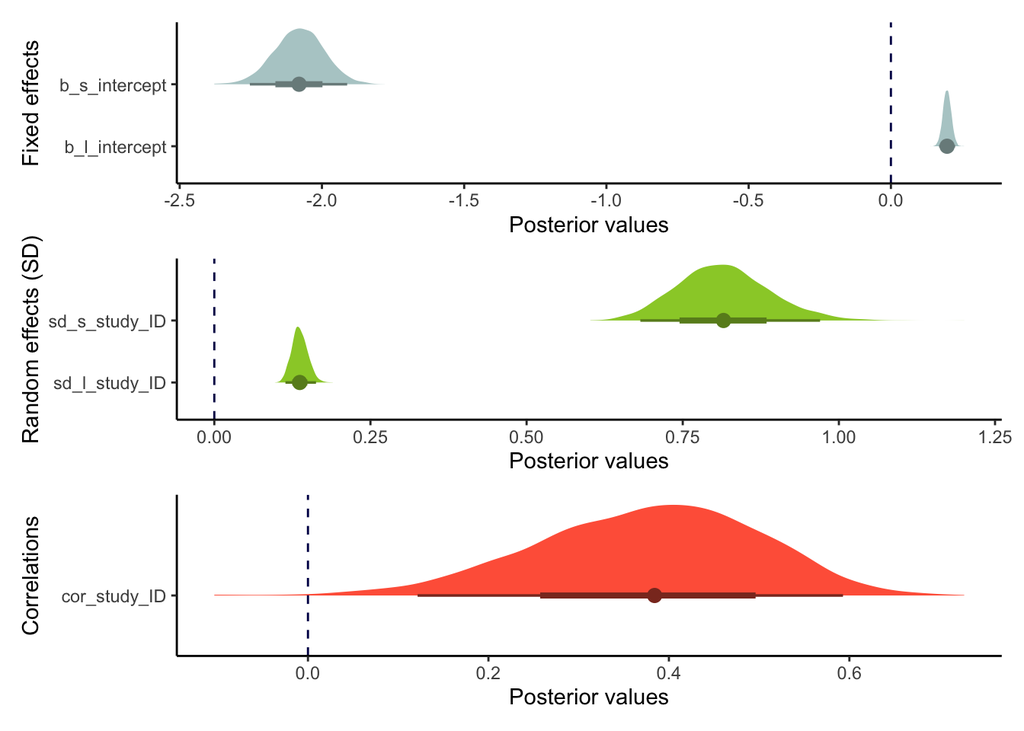

```r
# getting plots
plots_fit_ma1 <- list(
  visualize_fixed_effects(fit_ma1),
  visualize_random_effects(fit_ma1),
  visualize_correlations(fit_ma1)
)


plots_fit_ma1[[1]] / plots_fit_ma1[[2]] / plots_fit_ma1[[3]]
```

### 7.1.4 Quantifying heterogeneity on both location and scale parts

In our main text, we also propose heterogeneity measures for location-scale models. Here, we illustrate how to calculate them from the `brms` object.

For the total heterogeneity $I_{T}^2$, it can be computed with:

```r
# create a function to calculate "typical" sampling variance
compute_Vbar <- function(model) {
  W <- solve(model$data2$vcv)
  X <- make_standata(formula(model), data = model$data, data2 = model$data2)$X
  P <- W - W %*% X %*% solve(t(X) %*% W %*% X) %*% t(X) %*% W
  Vbar <- (nobs(model) - nrow(fixef(model)) / 2) / sum(diag(P))
  return(Vbar)
}
# typical sampling variance
Vbar <- compute_Vbar(fit_ma1)
# between-study variance of location part
sigma2_u = VarCorr(fit_ma1)$study_ID$sd[1,1]^2
# average within-study variance - Equation 25
sigma2bar_e = exp(2 * fixef(fit_ma1)[2,1] + 2 * VarCorr(fit_ma1)$study_ID$sd[2,1]^2)

# total I2
100 * (sigma2_u + sigma2bar_e) / (sigma2_u + sigma2bar_e + Vbar)
## [1] 99.6176
```

For the between-study heterogeneity $I_{B}^2$ (Equation 24), it can be computed with:

```r
100 * sigma2_u / (sigma2_u + sigma2bar_e + Vbar)
## [1] 24.01561
```

For the within-study heterogeneity $I_{W}^2$, it can be computed with:

```r
100 * sigma2bar_e / (sigma2_u + sigma2bar_e + Vbar)
## [1] 75.60198
```

We also propose mean-standardized heterogeneity measure in our paper. They also can be computed from `brms` object.

For between-study heterogeneity ($CV^{(l)}_{H(B)}$) of the location part (Equation 30), it can be computed with:

```r
sqrt(sigma2_u) / abs(fixef(fit_ma1)[1,1])
## [1] 0.6929387
```

For between-study heterogeneity ($CV^{(s)}_{H(B)}$) of the scale part (Equation 31), it can be computed with:

```r
sqrt(exp(VarCorr(fit_ma1)$study_ID$sd[2,1]^2) - 1)
## [1] 0.9715781
```

### 7.1.5 Notes

Three points are worth mentioning.

- 1. Pros and cons of estimating correlation between the location and scale between-study random effects

Recall in the above example (`brms` object `fit_ma1`), there is a positive correlation ($\rho_u = 0.38$) between the location and scale between-study random effects. On the one hand, $\rho_u$ has its biological interpretation as mean and variance are often found to be positively correlated, which is known as Taylor’s law. On the other hand, estimating $\rho_u$ could bring extra difficulties in model convergence. Therefore, one needs make informed decision about whether the $\rho_u$ should be included in the location-scale model.

- 2. It is important to account for random effects in both location and scale parts

In our paper, we propose one should fit location-scale models with the between-study effects in both parts as starting point. This is because this could allow for the examination of the heterogeneity in variance (heteroscedasticity). Biologically, heteroscedasticity could be associated certain biological phenomena and hypotheses. Methodologically, heteroscedasticity indicate location-scale meta-regression should be preferred over traditional meta-analytic approaches (which only have location part). Currently, only `brms` (`v2.22.0`) can support such location-scale models with the between-study effects in both parts.

- 3. Accounting for correlated sampling errors is important to location-scale model

Ignoring the correlation between sampling errors within the same study will lead to biased estimate of variance components, which are the response variable of the scale part of the location-scale model.

`brms` (`v2.22.0`) provides an effective way to account for correlated sampling errors. While the current version of `metafor` (`v4.7.53`) allows for correlated sampling errors, it does not allow for between-study effects in scale part. The current version of `blsmeta` (`0.1.0`) does not allow for correlated sampling errors.

One key step of accounting correlated sampling errors is to construct a variance-covariance matrix. `vcalc()` from `metafor` allows us easily do so. Let’s first use `vcalc()` to construct a variance-covariance matrix to capture the correlation between sampling errors within the same cluster (`population_ID`):

```r
# here correlated structure or cluster is population_ID
# assume a constant correlation coefficient of 0.5; it can make a best guess for your own dataset
vcv2 <- vcalc(vi = Var_dARR,
             cluster = population_ID,
             obs = es_ID, rho = 0.5,
             data = dat)
rownames(vcv2) <- dat$es_ID
colnames(vcv2) <- dat$es_ID
```

### 7.1.6 Multilevel location-scale meta-regression with a categorical moderator (biological variable)

In this section, we will illustrate how to fit a multilevel location-scale meta-regression with a categorical moderator. In the context of meta-analysis, we usually have two types of categorical moderator to explain variance in the data: (1) biological variable, and (2) methodological variable.

The biological moderator we used here is `habitat`, which indicates where animals live. It has two levels: aquatic vs. terrestrial.

Considering the trade-off of including random effects in the scale part of a location-scale meta-regression, we decide to fit a location-scale meta-regression without random effects in the scale part to **Example 1**. As mentioned earlier, doing so also allows us to compare results from `brms`, `blsmeta` and `metafor`.

#### 7.1.6.1 `brms`

A multilevel location-scale meta-regression with a biological categorical moderator can be fitted with `brms` syntax:

```r
# biological moderator
form_mr1 <- bf(dARR
            ~ 1  + habitat +
              (1|study_ID) + # this is u_l
              (1|gr(es_ID, cov = vcv)), # this is m
            sigma ~ 1 + habitat
)


# create priorss
prior_mr1 <- default_prior(form_mr1,
                        data = dat,
                        data2 = list(vcv = vcv),
                        family = gaussian()
)

# fixing the variance to 1 (meta-analysis)
prior_mr1$prior[5] = "constant(1)"
prior_mr1

# fitting model
fit_mr1 <- brm(form_mr1,
            data = dat,
            data2 = list(vcv = vcv),
            chains = 2,
            cores = 2,
            iter = 3000,
            warmup = 2000,
            prior = prior_mr1,
            control = list(adapt_delta = 0.95, max_treedepth = 15)
)

# save this as rds
saveRDS(fit_mr1, here("Rdata", "fit_mr1.rds"))
```

Check the results:

```r
fit_mr1 <- readRDS(here("Rdata", "fit_mr1.rds"))
summary(fit_mr1)
##  Family: gaussian
##   Links: mu = identity; sigma = log
## Formula: dARR ~ 1 + habitat + (1 | study_ID) + (1 | gr(es_ID, cov = vcv))
##          sigma ~ 1 + habitat
##    Data: dat (Number of observations: 1089)
##   Draws: 2 chains, each with iter = 3000; warmup = 2000; thin = 1;
##          total post-warmup draws = 2000
##
## Multilevel Hyperparameters:
## ~es_ID (Number of levels: 1089)
##               Estimate Est.Error l-95% CI u-95% CI Rhat Bulk_ESS Tail_ESS
## sd(Intercept)     1.00      0.00     1.00     1.00   NA       NA       NA
##
## ~study_ID (Number of levels: 150)
##               Estimate Est.Error l-95% CI u-95% CI Rhat Bulk_ESS Tail_ESS
## sd(Intercept)     0.13      0.01     0.11     0.16 1.00      543     1180
##
## Regression Coefficients:
##                          Estimate Est.Error l-95% CI u-95% CI Rhat Bulk_ESS
## Intercept                    0.22      0.02     0.19     0.25 1.00      774
## sigma_Intercept             -1.39      0.03    -1.44    -1.33 1.00     1376
## habitatterrestrial          -0.16      0.04    -0.23    -0.09 1.01      289
## sigma_habitatterrestrial    -1.18      0.08    -1.33    -1.02 1.00     1164
##                          Tail_ESS
## Intercept                    1290
## sigma_Intercept              1678
## habitatterrestrial            781
## sigma_habitatterrestrial     1582
##
## Draws were sampled using sampling(NUTS). For each parameter, Bulk_ESS
## and Tail_ESS are effective sample size measures, and Rhat is the potential
## scale reduction factor on split chains (at convergence, Rhat = 1).
```

#### 7.1.6.2 `blsmeta`

A similar meta-regression based on `blsmeta` syntax is:

```r
fit_mr10 <- blsmeta(yi = dARR,
               vi = Var_dARR,
               es_id = es_ID,
               study_id = study_ID,
               mods = ~ 1 + habitat,
               mods_scale2 = ~ 1 + habitat,
               data = dat)
#save
saveRDS(fit_mr10, here("Rdata", "fit_mr10.rds"))
```

Check the results:

```r
fit_mr10  <- readRDS(here("Rdata", "fit_mr10.rds"))
print(fit_mr10)
## Model: Three-Level
## Studies2: 1089
## Studies3: 150
## Samples: 20000 (4 chains)
## Location Formula: ~ 1 + habitat
## Scale2 Formula: ~ 1 + habitat
## Scale3 Formula: ~ 1
## Note: 'Scale' on standard deviation scale
## ------
## Scale2:
##                    Post.mean Post.sd Cred.lb Cred.ub Rhat
## (Intercept)            -1.39    0.03   -1.45   -1.33 1.02
## habitatterrestrial     -1.17    0.09   -1.33   -1.00 1.00
##
## Scale3:
##               Post.mean Post.sd Cred.lb Cred.ub Rhat
## sd(Intercept)      0.13    0.01    0.11    0.16 1.33
##
## Location:
##                    Post.mean Post.sd Cred.lb Cred.ub Rhat
## (Intercept)             0.21    0.01    0.18    0.24 1.28
## habitatterrestrial     -0.15    0.03   -0.21   -0.08 1.24
##
## ------
## Date: Fri Apr 18 16:05:57 2025
```

As you can see, the results from `blsmeta` match well with those from `brms`. There are only slight differences, which are likely due to the different priors used by `blsmeta` and `brms`.

#### 7.1.6.3 `metafor`

The current version of `metafor` also can be used to fit the above location-scale meta-regression. It also could account for correlated errors as `brms` did. The syntax based on `metafor` syntax is:

```r
mr1_mod <- rma.mv(yi = dARR,
                  V =  vcv,
                  mod = ~ habitat,
                  random = list(~1 | study_ID,
                                ~habitat | es_ID),
                  struct = "DIAG",
                  data = dat,
                  test = "t",
                  sparse = TRUE,
                  control=list(optimizer="optim", optmethod="Nelder-Mead")
)
```

Check the results:

```r
summary(mr1_mod)
##
## Multivariate Meta-Analysis Model (k = 1089; method: REML)
##
##    logLik   Deviance        AIC        BIC       AICc
## -119.3461   238.6922   248.6922   273.6481   248.7477
##
## Variance Components:
##
##             estim    sqrt  nlvls  fixed    factor
## sigma^2    0.0167  0.1291    150     no  study_ID
##
## outer factor: es_ID   (nlvls = 1089)
## inner factor: habitat (nlvls = 2)
##
##             estim    sqrt  k.lvl  fixed        level
## tau^2.1    0.0624  0.2497    929     no      aquatic
## tau^2.2    0.0058  0.0763    160     no  terrestrial
##
## Test for Residual Heterogeneity:
## QE(df = 1087) = 45754.7556, p-val < .0001
##
## Test of Moderators (coefficient 2):
## F(df1 = 1, df2 = 1087) = 20.9131, p-val < .0001
##
## Model Results:
##
##                     estimate      se     tval    df    pval    ci.lb    ci.ub
## intrcpt               0.2180  0.0161  13.5460  1087  <.0001   0.1864   0.2495
## habitatterrestrial   -0.1571  0.0344  -4.5731  1087  <.0001  -0.2246  -0.0897
##
## intrcpt             ***
## habitatterrestrial  ***
##
## ---
## Signif. codes:  0 '***' 0.001 '**' 0.01 '*' 0.05 '.' 0.1 ' ' 1
```

Perfect! The results from `metafor` also align with those from `brms` and `blsmeta`. If the comparisons are not clear, let’s make a table to show the main parameter estimates:

```r
res1 <- fixef(fit_mr1)
res2 <- tau2(fit_mr10, newdata_scale2 = data.frame(habitat = c(0,1)), newdata_scale3 = data.frame(1))
res22 <- fixef(fit_mr10)
res3 <- summary(mr1_mod)

t <- data.frame(Software = c("brms", "blsmeta", "metafor"),
           Aquatic_location = c(res1[1,1], res22[1,1], res3$b[1]),
           Terrestrial_location = c(res1[3,1] + res1[1,1], res22[2,1] + res22[1,1], res3$b[2] + res3$b[1]),
           Aquatic_scale = c(exp(res1[2,1])^2, res2$level_two[1,1]^2, res3$tau2[1]),
           Terrestrial_scale = c(exp(res1[4,1] + res1[2,1])^2, res2$level_two[2,1]^2, res3$tau2[2])
           ) %>% dfround(3)
```

[output not shown]

### 7.1.7 Visualizing meta-regression with a biological categorical variable

Let’s visualize the parameter estimates of `habitat` in both location and scale parts:

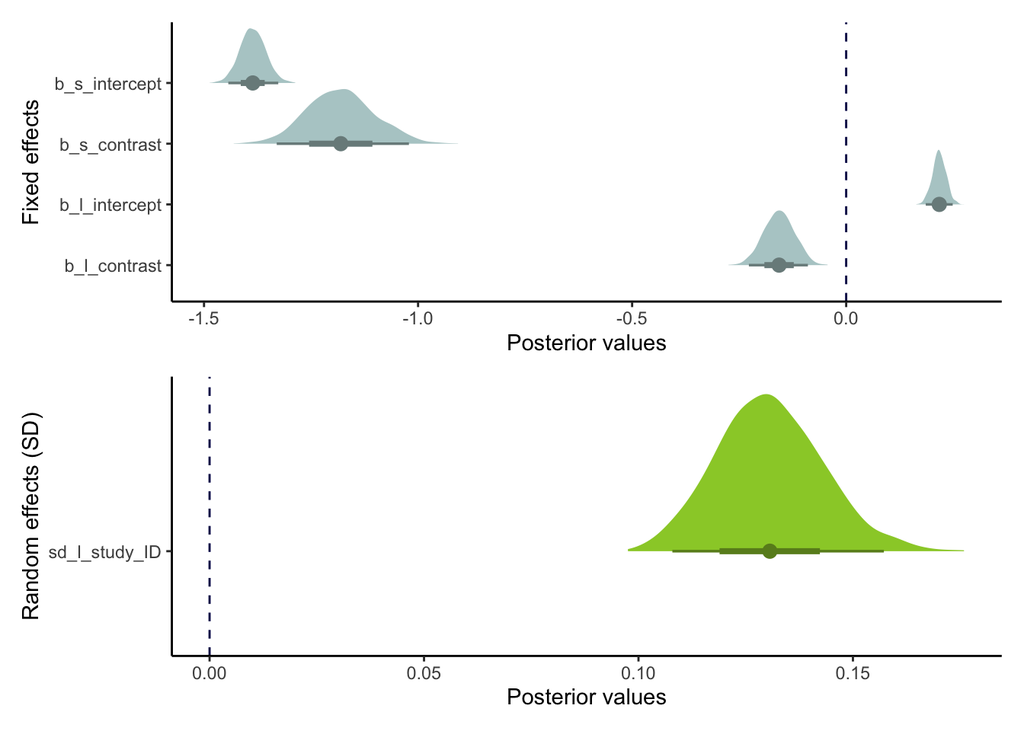

```r
# getting plots
plots_fit_mr1 <- list(
  visualize_fixed_effects(fit_mr1),
  visualize_random_effects(fit_mr1)
)

plots_fit_mr1[[1]] / plots_fit_mr1[[2]]
```

`orchard_plot` from `orchaRd` also provides an alternative way to visualize results:

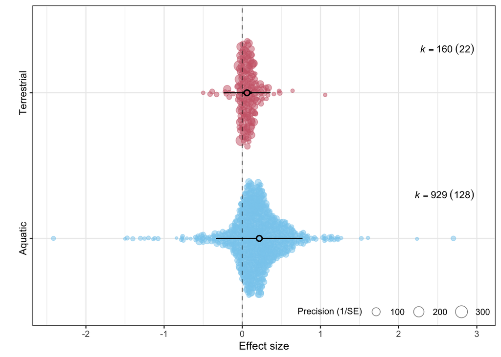

```r
orchard_plot(mr1_mod, mod = "habitat", group = "study_ID", xlab = "Effect size")
```

### 7.1.8 Multilevel location-scale meta-regression with a categorical moderator (methodological variable)

Sometimes, ones might be interested in examining a methodological categorical moderator. The principle is exactly the same as that in the biological categorical moderator. Let’s use the methodological variable `method` for the illustration. The syntax is fairly simple if you followed the above well: just replace `habitat` with `method` in the above syntax.

#### 7.1.8.1 `brms`

The `brms` syntax for fitting a multilevel location-scale meta-regression with a methodological categorical moderator is:

```r
form_mr2 <- bf(dARR
            ~ 1  + method +
              (1|study_ID) + # this is u
              (1|gr(es_ID, cov = vcv)), # this is m
            sigma ~ 1 + method
)


# create priorss
prior_mr2 <- default_prior(form_mr2,
                        data = dat,
                        data2 = list(vcv = vcv),
                        family = gaussian()
)

# fixing the variance to 1 (meta-analysis)
prior_mr2$prior[5] = "constant(1)"
prior_mr2
# fit model
fit_mr2 <- brm(form_mr2,
            data = dat,
            data2 = list(vcv = vcv),
            chains = 2,
            cores = 2,
            iter = 3000,
            warmup = 2000,
            #backend = "cmdstanr",
            prior = prior_mr2,
            #threads = threading(9),
            control = list(adapt_delta = 0.99, max_treedepth = 15)
)

# save this as rds
saveRDS(fit_mr2, here("Rdata", "fit_mr2.rds"))
```

Check the results:

```r
fit_mr2 <- readRDS(here("Rdata", "fit_mr2.rds"))
summary(fit_mr2)
##  Family: gaussian
##   Links: mu = identity; sigma = log
## Formula: dARR ~ 1 + method + (1 | study_ID) + (1 | gr(es_ID, cov = vcv))
##          sigma ~ 1 + method
##    Data: dat (Number of observations: 1089)
##   Draws: 2 chains, each with iter = 3000; warmup = 2000; thin = 1;
##          total post-warmup draws = 2000
##
## Multilevel Hyperparameters:
## ~es_ID (Number of levels: 1089)
##               Estimate Est.Error l-95% CI u-95% CI Rhat Bulk_ESS Tail_ESS
## sd(Intercept)     1.00      0.00     1.00     1.00   NA       NA       NA
##
## ~study_ID (Number of levels: 150)
##               Estimate Est.Error l-95% CI u-95% CI Rhat Bulk_ESS Tail_ESS
## sd(Intercept)     0.12      0.01     0.10     0.15 1.00      718     1373
##
## Regression Coefficients:
##                         Estimate Est.Error l-95% CI u-95% CI Rhat Bulk_ESS
## Intercept                   0.24      0.02     0.21     0.28 1.00     1563
## sigma_Intercept            -1.57      0.06    -1.68    -1.45 1.00     1806
## methodpersisitent          -0.07      0.02    -0.10    -0.03 1.00     3050
## sigma_methodpersisitent     0.21      0.07     0.07     0.34 1.00     1967
##                         Tail_ESS
## Intercept                   1667
## sigma_Intercept             1343
## methodpersisitent           1665
## sigma_methodpersisitent     1364
##
## Draws were sampled using sampling(NUTS). For each parameter, Bulk_ESS
## and Tail_ESS are effective sample size measures, and Rhat is the potential
## scale reduction factor on split chains (at convergence, Rhat = 1).
```

#### 7.1.8.2 `blsmeta`

The `blsmeta` syntax for fitting a multilevel location-scale meta-regression with a methodological categorical moderator is:

```r
fit_mr12 <- blsmeta(yi = dARR,
                 vi = Var_dARR,
                 es_id = es_ID,
                 study_id = study_ID,
                 mods = ~ 1 + method,
                 mods_scale2 = ~ 1 + method,
                 data = dat)
#save
saveRDS(fit_mr12, here("Rdata", "fit_mr12.rds"))
```

Check the results:

```r
# read in rds
fit_mr12 <- readRDS(here("Rdata", "fit_mr12.rds"))
print(fit_mr12)
## Model: Three-Level
## Studies2: 1089
## Studies3: 150
## Samples: 20000 (4 chains)
## Location Formula: ~ 1 + method
## Scale2 Formula: ~ 1 + method
## Scale3 Formula: ~ 1
## Note: 'Scale' on standard deviation scale
## ------
## Scale2:
##                   Post.mean Post.sd Cred.lb Cred.ub Rhat
## (Intercept)           -1.65    0.06   -1.78   -1.53 1.00
## methodpersisitent      0.22    0.07    0.07    0.37 1.01
##
## Scale3:
##               Post.mean Post.sd Cred.lb Cred.ub Rhat
## sd(Intercept)      0.13    0.01    0.11    0.16 1.22
##
## Location:
##                   Post.mean Post.sd Cred.lb Cred.ub Rhat
## (Intercept)            0.24    0.02    0.20    0.28 1.16
## methodpersisitent     -0.07    0.02   -0.10   -0.03 1.07
##
## ------
## Date: Fri Apr 18 16:06:12 2025
```

#### 7.1.8.3 `metafor`

The current version of `metafor` also can be used to fit the above location-scale meta-regression. It also could account for correlated errors as `brms` did. The syntax based on `metafor` syntax is:

```r
mr2_mod <- rma.mv(yi = dARR,
                  V =  vcv,
                  mod = ~ method,
                  random = list(~1 | study_ID,
                                ~method | es_ID),
                  struct = "DIAG",
                  data = dat,
                  test = "t",
                  sparse = TRUE,
                  control=list(optimizer="optim", optmethod="Nelder-Mead")
)
```

Check the results:

```r
summary(mr2_mod)
##
## Multivariate Meta-Analysis Model (k = 1089; method: REML)
##
##    logLik   Deviance        AIC        BIC       AICc
## -191.0646   382.1292   392.1292   417.0851   392.1847
##
## Variance Components:
##
##             estim    sqrt  nlvls  fixed    factor
## sigma^2    0.0177  0.1329    150     no  study_ID
##
## outer factor: es_ID  (nlvls = 1089)
## inner factor: method (nlvls = 2)
##
##             estim    sqrt  k.lvl  fixed        level
## tau^2.1    0.0362  0.1904    287     no      initial
## tau^2.2    0.0569  0.2386    802     no  persisitent
##
## Test for Residual Heterogeneity:
## QE(df = 1087) = 50559.9341, p-val < .0001
##
## Test of Moderators (coefficient 2):
## F(df1 = 1, df2 = 1087) = 15.1833, p-val = 0.0001
##
## Model Results:
##
##                    estimate      se     tval    df    pval    ci.lb    ci.ub
## intrcpt              0.2423  0.0180  13.4565  1087  <.0001   0.2070   0.2777
## methodpersisitent   -0.0636  0.0163  -3.8966  1087  0.0001  -0.0956  -0.0316
##
## intrcpt            ***
## methodpersisitent  ***
##
## ---
## Signif. codes:  0 '***' 0.001 '**' 0.01 '*' 0.05 '.' 0.1 ' ' 1
```

The results of both location and scale parts from `brms`, `lsmeta`, and `metafor` still align well.

### 7.1.9 Visualizing meta-regression with a methodological categorical variable

Let’s visualize the parameter estimates of `method` in both location and scale parts:

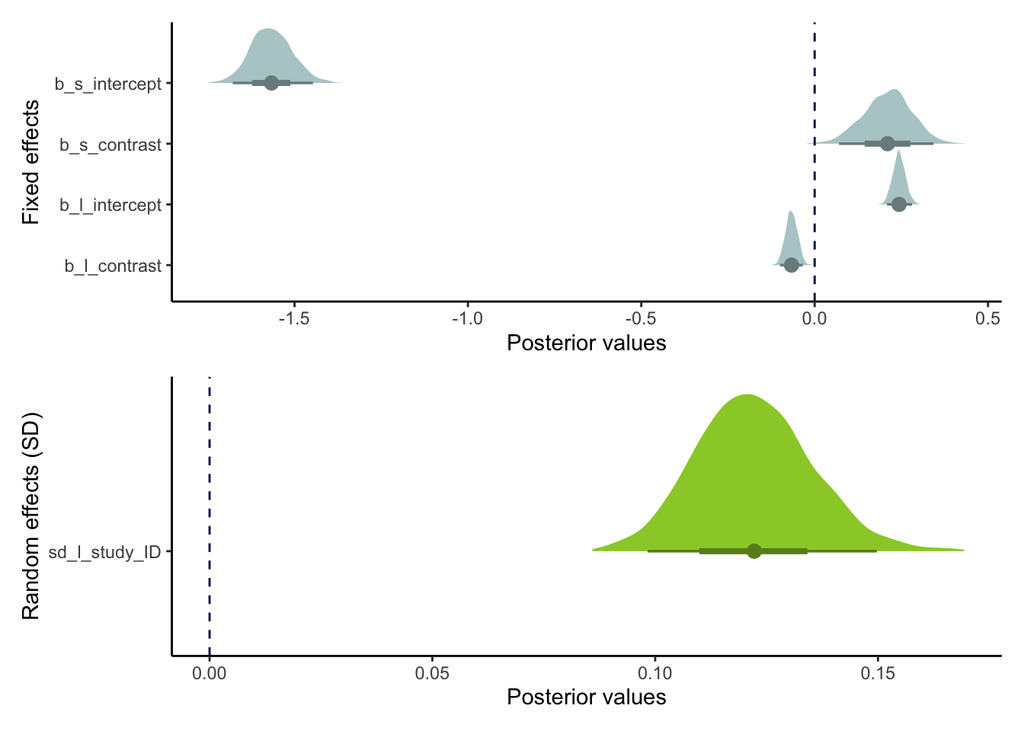

```r
# getting plots
plots_fit_mr2 <- list(
  visualize_fixed_effects(fit_mr2),
  visualize_random_effects(fit_mr2)
)

plots_fit_mr2[[1]] / plots_fit_mr2[[2]]
```

### 7.1.10 Bonus 1: Location-scale mulitlevel meta-regression with the between-study random effect in the scale part

```r
# biological moderator
form_mr1b <- bf(dARR
            ~ 1  + habitat +
              (1|p|study_ID) + # this is u_l
              (1|gr(es_ID, cov = vcv)), # this is m
            sigma ~ 1 + habitat +
              (1|p|study_ID)
)


# create priorss
prior_mr1b <- default_prior(form_mr1b,
                        data = dat,
                        data2 = list(vcv = vcv),
                        family = gaussian()
)

# fixing the variance to 1 (meta-analysis)
prior_mr1b$prior[5] = "constant(1)"
prior_mr1b

# fitting model
fit_mr1b <- brm(form_mr1b,
            data = dat,
            data2 = list(vcv = vcv),
            chains = 2,
            cores = 2,
            iter = 10000,
            warmup = 5000,
            prior = prior_mr1b,
            control = list(adapt_delta = 0.95, max_treedepth = 15)
)

# save this as rds
saveRDS(fit_mr1b, here("Rdata", "fit_mr1b.rds"))
```

Check the results:

```r
fit_mr1b <- readRDS(here("Rdata", "fit_mr1b.rds"))
summary(fit_mr1b)
##  Family: gaussian
##   Links: mu = identity; sigma = log
## Formula: dARR ~ 1 + habitat + (1 | p | study_ID) + (1 | gr(es_ID, cov = vcv))
##          sigma ~ 1 + habitat + (1 | p | study_ID)
##    Data: dat (Number of observations: 1089)
##   Draws: 2 chains, each with iter = 10000; warmup = 5000; thin = 1;
##          total post-warmup draws = 10000
##
## Multilevel Hyperparameters:
## ~es_ID (Number of levels: 1089)
##               Estimate Est.Error l-95% CI u-95% CI Rhat Bulk_ESS Tail_ESS
## sd(Intercept)     1.52      0.13     1.27     1.78 1.10       16      253
##
## ~study_ID (Number of levels: 150)
##                                Estimate Est.Error l-95% CI u-95% CI Rhat
## sd(Intercept)                      0.46      0.32     0.13     0.87 1.83
## sd(sigma_Intercept)                1.36      0.65     0.62     2.42 1.83
## cor(Intercept,sigma_Intercept)     0.70      0.25     0.26     0.97 1.83
##                                Bulk_ESS Tail_ESS
## sd(Intercept)                         3       57
## sd(sigma_Intercept)                   3       51
## cor(Intercept,sigma_Intercept)        3       50
##
## Regression Coefficients:
##                          Estimate Est.Error l-95% CI u-95% CI Rhat Bulk_ESS
## Intercept                    0.65      0.38     0.24     1.07 1.83        3
## sigma_Intercept             -1.19      0.86    -2.21     0.06 1.83        3
## habitatterrestrial           2.36      2.57    -0.50     5.15 1.83        3
## sigma_habitatterrestrial     1.67      2.21    -1.31     4.19 1.83        3
##                          Tail_ESS
## Intercept                      54
## sigma_Intercept                46
## habitatterrestrial             54
## sigma_habitatterrestrial       49
##
## Draws were sampled using sampling(NUTS). For each parameter, Bulk_ESS
## and Tail_ESS are effective sample size measures, and Rhat is the potential
## scale reduction factor on split chains (at convergence, Rhat = 1).
```

The effect sample size (ESS) is away too low and we conclude that this model is over-parametrized.

### 7.1.11 Bonus 2: Location-scale phylogenetic meta-regression

Ecological and evolutionary meta-analyses often deal with species-level data. The shared evolutionary history among different species could affect both the mean and variance of the traits. In our paper, we propose a phylogenetic location-scale meta-regression (Equations (37) to (43)) to examine whether certain clades or evolutionary lineages exhibit inherently different levels of heterogeneity by species-level moderators (e.g., two different species groups according to their taxonomy).

While such a phylogenetic location-scale meta-regression looks complex, `brms` is capable enough of implementing it.

Let’s start by building a phylogenetic tree:

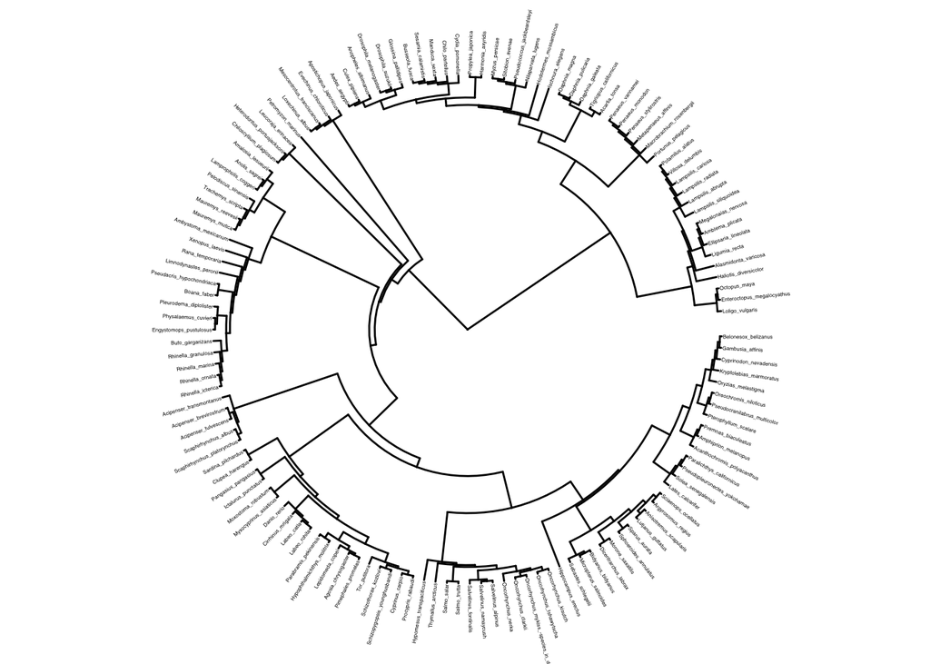

```r
# read in the tree
tree <- read.tree(here("data", "phylo_tree.tre"))
ggtree(tree, layout="circular",ladderize=TRUE) +
   geom_tiplab(size=1)
```

Then, we use `vcv()` to impute the correlation matrix to account for the shared evolutionary history.

```r
# phylogenetic correlation matrix
mat <- vcv(tree, cor=T)
```

To give you an intuition of what a phylogenetic correlation matrix looks like, let’s check the first correlations between the first 4 species:

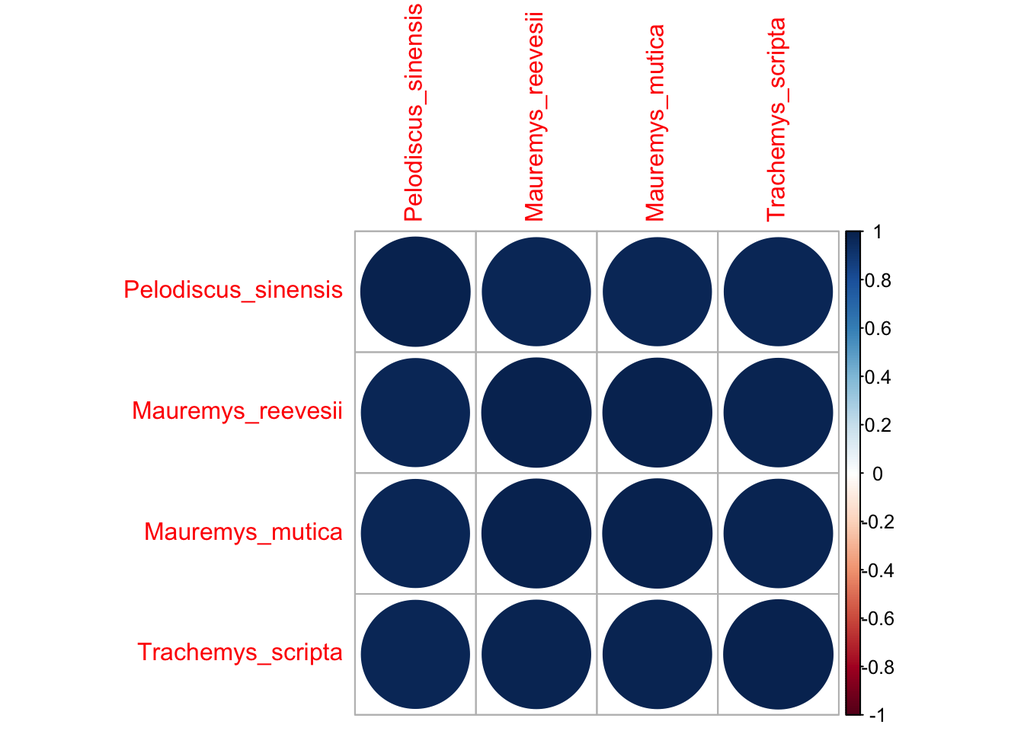

```r
mat[1:4, 1:4]
##                     Pelodiscus_sinensis Mauremys_reevesii Mauremys_mutica
## Pelodiscus_sinensis           1.0000000         0.9781022       0.9781022
## Mauremys_reevesii             0.9781022         1.0000000       0.9927007
## Mauremys_mutica               0.9781022         0.9927007       1.0000000
## Trachemys_scripta             0.9781022         0.9854015       0.9854015
##                     Trachemys_scripta
## Pelodiscus_sinensis         0.9781022
## Mauremys_reevesii           0.9854015
## Mauremys_mutica             0.9854015
## Trachemys_scripta           1.0000000
corrplot::corrplot(mat[1:4, 1:4])
```

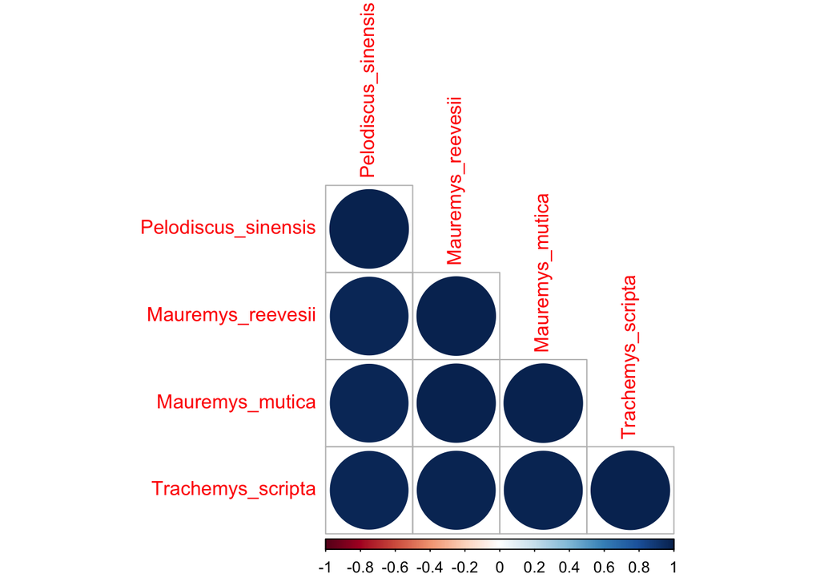

```r
corrplot::corrplot(mat[1:4, 1:4], method = "circle", type = "lower")
```

We can see that they are highly correlated.

#### 7.1.11.1 Location-scale phylogenetic meta-regression based on `brms`

Then, we use specify `1|gr(phylogeny, cov = mat)` to account for phylogenetic correlations:

```r
form_mr1p <- bf(dARR
              ~ 1 + habitat +
              (1|gr(phylogeny, cov = mat)) + # this is a
              (1|species_ID) + # this is s
              (1|study_ID) + # this is u
              (1|gr(es_ID, cov = vcv)), # this is m
            sigma ~ 1 + habitat
)


# create priorss
prior_mr1p <- default_prior(form_mr1p,
                        data = dat,
                        data2 = list(vcv = vcv, mat = mat),
                        family = gaussian()
)
# fixing the variance to 1 (meta-analysis)
prior_mr1p$prior[5] = "constant(1)"
prior_mr1p
# fit model

fit_mr1p <- brm(form_mr1p,
            data = dat,
            data2 = list(vcv = vcv, mat = mat),
            chains = 2,
            cores = 2,
            iter = 10000,
            warmup = 5000,
            prior = prior_mr1p,
            control = list(adapt_delta = 0.99, max_treedepth = 15)
)

# save this as rds
saveRDS(fit_mr1p, here("Rdata", "fit_mr1p.rds"))
```

Check the results:

```r
fit_mr1p<- readRDS(here("Rdata", "fit_mr1p.rds"))
summary(fit_mr1p)
##  Family: gaussian
##   Links: mu = identity; sigma = log
## Formula: dARR ~ 1 + habitat + (1 | gr(phylogeny, cov = mat)) + (1 | species_ID) + (1 | study_ID) + (1 | gr(es_ID, cov = vcv))
##          sigma ~ 1 + habitat
##    Data: dat (Number of observations: 1089)
##   Draws: 2 chains, each with iter = 10000; warmup = 5000; thin = 1;
##          total post-warmup draws = 10000
##
## Multilevel Hyperparameters:
## ~es_ID (Number of levels: 1089)
##               Estimate Est.Error l-95% CI u-95% CI Rhat Bulk_ESS Tail_ESS
## sd(Intercept)     1.00      0.00     1.00     1.00   NA       NA       NA
##
## ~phylogeny (Number of levels: 138)
##               Estimate Est.Error l-95% CI u-95% CI Rhat Bulk_ESS Tail_ESS
## sd(Intercept)     0.12      0.05     0.02     0.23 1.00     1322     1720
##
## ~species_ID (Number of levels: 138)
##               Estimate Est.Error l-95% CI u-95% CI Rhat Bulk_ESS Tail_ESS
## sd(Intercept)     0.03      0.02     0.00     0.08 1.00     1075     1695
##
## ~study_ID (Number of levels: 150)
##               Estimate Est.Error l-95% CI u-95% CI Rhat Bulk_ESS Tail_ESS
## sd(Intercept)     0.11      0.02     0.08     0.14 1.00     1754     2362
##
## Regression Coefficients:
##                          Estimate Est.Error l-95% CI u-95% CI Rhat Bulk_ESS
## Intercept                    0.22      0.07     0.06     0.37 1.00     3931
## sigma_Intercept             -1.39      0.03    -1.45    -1.33 1.00     8439
## habitatterrestrial          -0.17      0.05    -0.27    -0.06 1.00     5172
## sigma_habitatterrestrial    -1.18      0.08    -1.34    -1.02 1.00     6755
##                          Tail_ESS
## Intercept                    4578
## sigma_Intercept              7640
## habitatterrestrial           6639
## sigma_habitatterrestrial     7115
##
## Draws were sampled using sampling(NUTS). For each parameter, Bulk_ESS
## and Tail_ESS are effective sample size measures, and Rhat is the potential
## scale reduction factor on split chains (at convergence, Rhat = 1).
```

#### 7.1.11.2 Phylogenetic signal

The phylogenetic signal (or phylogenetic heritability; Equation 40) can be computed as:

```r
(VarCorr(fit_mr1p)$phylogeny$sd[1]^2 / (VarCorr(fit_mr1p)$phylogeny$sd[1]^2 + VarCorr(fit_mr1p)$species_ID$sd[1]^2))
## [1] 0.9386124
```

We see that a relatively large phylogenetic signal (0.94). Visualization also confirms that there is a large phylogenetic variance:

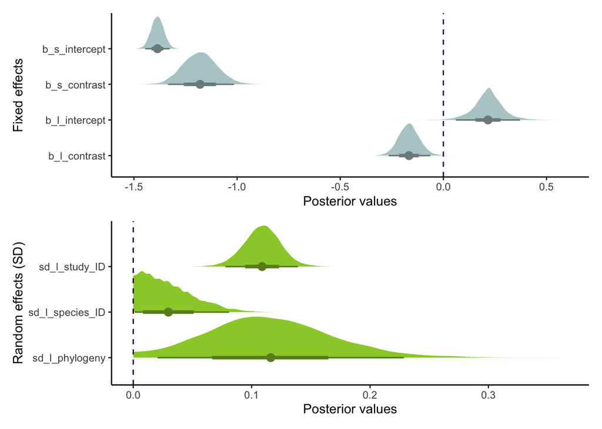

```r
# getting plots
plots_fit_mr1p <- list(
  visualize_fixed_effects(fit_mr1p),
  visualize_random_effects(fit_mr1p)
)

plots_fit_mr1p[[1]] / plots_fit_mr1p[[2]]
```

## 7.2 Example 2: Multilevel location-scale meta-regression with a continuous moderator

### 7.2.1 Data

We use the data (hereafter **Example 2**) from the following paper:

> Midolo, G. et al. (2019). Global patterns of intraspecific leaf trait responses to elevation. Global Change Biology, 25(7), 2485–2498.

**Example 2** involves using a dataset (`elevation.csv`) to meta-analyse the impact of elevation on an intraspecific leaf trait (`Narea`). Let’s load `elevation.csv` into `R`, and do some basic pre-processes:

```r
# load
dat <- read.csv(here("data", "elevation.csv"))
# calculate es
# filter data Narea
dat <- dat %>% filter(trait == "Narea")

dat$study_ID <- as.factor(dat$Study_ID)
dat$es_ID <- as.factor(1:nrow(dat))

# using escalc use ROM

dat <- escalc(measure = "ROM",
              m1i = treatment,
              m2i = control,
              sd1i = sd_treatment,
              sd2i = sd_control,
              n1i = n_treatment,
              n2i = n_control,
              data = dat)


# rename for the consistency
dat$study_ID <- as.factor(dat$Study_ID)
dat$es_ID <- as.factor(1:nrow(dat))

# selecte varaibles we need
dat <- dat %>% select(yi, vi, es_ID, study_ID, elevation_log)
str(dat)
## Classes 'escalc' and 'data.frame':   204 obs. of  5 variables:
##  $ yi           : num  -0.1328 -0.2367 -0.1705 -0.0942 -0.0638 ...
##   ..- attr(*, "ni")= int [1:204] 10 10 10 10 10 10 10 10 10 10 ...
##   ..- attr(*, "measure")= chr "ROM"
##  $ vi           : num  0.01241 0.01224 0.01256 0.02234 0.00886 ...
##  $ es_ID        : Factor w/ 204 levels "1","2","3","4",..: 1 2 3 4 5 6 7 8 9 10 ...
##  $ study_ID     : Factor w/ 29 levels "4","5","6","7",..: 3 3 3 3 3 3 3 3 3 3 ...
##  $ elevation_log: num  5.22 5.74 5.87 4.91 5.22 ...
##  - attr(*, "yi.names")= chr "yi"
##  - attr(*, "vi.names")= chr "vi"
##  - attr(*, "digits")= Named num [1:9] 4 4 4 4 4 4 4 4 4
##   ..- attr(*, "names")= chr [1:9] "est" "se" "test" "pval" ...
```

The key variables:

`yi`: effect size estimate, quantifying tje impact of elevation on intraspecific leaf trait

`vi`: sampling variance corresponding to `yi`

`elevation_log`: elevation (log scale), which will be used as the continuous moderator in a multilevel location-scale meta-regression